# The Bootstrap (Part 1)

Stanford University, Spring 2016, STATS 205

## What Happened So Far

- We want to compute functionals \(\theta = T(F)\), e.g.
  - the mean: \(T(F) = \int x \, dF(x) = \int x \, f(x) \, dx\)
  - the median: \(T(F) = F^{-1}(1/2)\)
- Parameter of interest \(\theta\) is functional of unkown \(F\)
- Assumptions on \(f(x)\) relatively weak, e.g. symmetric around zero
- We tested \(\theta = \theta_0\) from a sample \(\boldsymbol{x} = \{ x_1,x_2,\dots,x_n \}\) drawn from distribution \(F\) by comparing the observed statistic \(s(\boldsymbol{x})\) to the null distribution of test statistics
- We introduced estimators \(\widehat{\theta}\) and confidence intervals from a sample
- We quantified the robustness of estimators \(\widehat{\theta}\) to outliers

## Background

- Computer more powerful, resampling procedure more widespread
- The bootstrap is another tool to measure error in an estimate or significance of a hypothesis
- A bootstrap sample is a sample from the original sample taken (with replacement)
- This works when the histogram of the sample is representative of the population
- In other words, the histogram of the sample resembles the pdf of the random variable
- Drawing sample from the histogram is then the same as drawing samples from the population
- Thus yields an estimate of the sampling distribution of the statistic \(s(\boldsymbol{x})\) or estimate \(\widehat{\theta}\)

## Plug-in Principle

- The data are drawn independently and identically from a unknown distribution \(F\)
- The bootstrap supposes that the empirical distribution \(F_n\) is a good description of the unknown distribution \(F\)
- The *plugin-in estimate* of a parameter \(\theta = T(F)\) is define as \[\widehat{\theta} = T(F_n)\]
- This way one can draw as many samples from \(F_n\) to compute sample variability of all kinds of \(s(\boldsymbol{x}^*)\), e.g. the sample mean, sample median
- This is done via choosing \(n\) samples with replacement (you can pick the same sample multiple times)

## Plug-in Principle

- We observe the empirical distribution \(F_n\) \[ F_n(t) = \frac{1}{n} \sum_{i=1}^n I(x_i \le t) \]
- In other words, the distribution that puts mass \(1/n\) at each \(x_i\)
- Denote bootstrap sample from \(F_n\) (sample with replacement) as \[\boldsymbol{x}^* = \left[ x_1^*,x_2^*,\dots,x_n^* \right]^T\]
- Estimate based on original observations \(\widehat{\theta}^* = s(\boldsymbol{x}^*)\)
- Denote a collection of \(B\) bootstrap samples as \(\widehat{\theta}^*_1,\widehat{\theta}^*_2,\dots,\widehat{\theta}^*_B\)

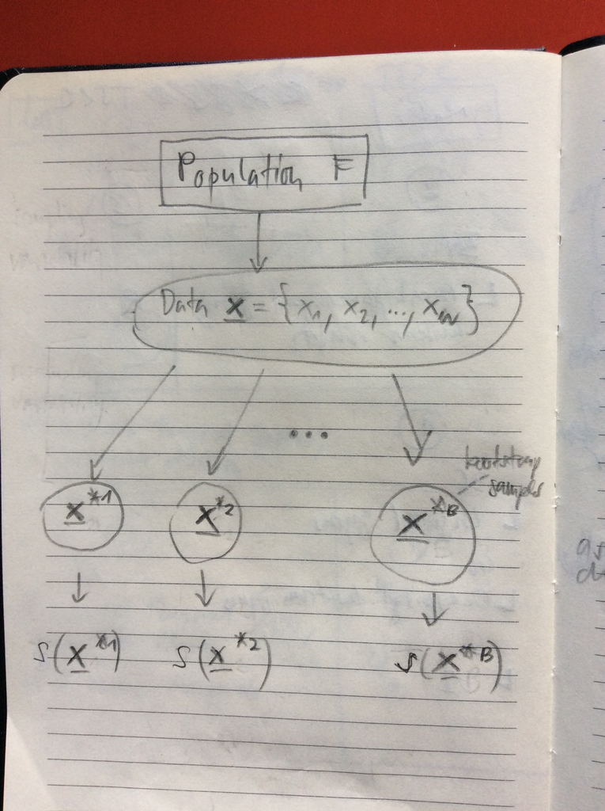

## Percentile Confidence Intervals

- Order bootstrap samples: \(\widehat{\theta}^*_{(1)} \le \widehat{\theta}^*_{(2)} \le \dots \le \widehat{\theta}^*_{(B)}\)
- Let \(m = \alpha/2 \times B\) then
- we get the approximate \((1-\alpha) \times 100\%\) confidence interval \[\left( \widehat{\theta}^*_{(m)},\widehat{\theta}^*_{(B-m)} \right)\]

## Paired Problem

- Consider the paired problem with \(d_1,\dots,d_n\) are the differences
- In the bootstrap sample \(d_i\) and \(-d_i\) each have probability \(1/2n\) of being selected
- This forms an estimate of the null distribution of the test statistic \(T\)
- Then \[\text{p-value } = \frac{\#\{T_i^*\ge T_0\}}{B}\]

## One Sample Location Problem

- Test the hypothesis: \[ H_0: \theta = \theta_0 \text{ versus } \theta > \theta_0 \]
- We have to make sure that the null hypothesis is true, so we take our bootstrap samples from \[x_1-\widehat{\theta}+\theta_0,\dots,x_n-\widehat{\theta}+\theta_0\]
- Then \[\text{p-value } = \frac{\#\{\widehat{\theta}_i^*\ge \widehat{\theta}\}}{B}\]

## Two Sources of Errors

- Sampling variability:  
  We only have a sample of size \(n\) and not the entire population
- Bootstrap resampling variability:  
  We only use \(B\) bootstrap samples rather than an infinite number

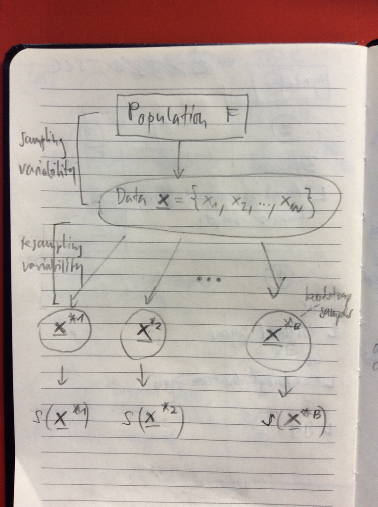

## Two Sources of Errors

- The bootstrap estimate of a standard error \(\widehat{\operatorname{se}}_B\) of a statistic \(s\) \[\widehat{\operatorname{se}}_B = \left( \frac{1}{B} \sum_{b=1}^B (s(\boldsymbol{x}^{*b})-\bar{s})^2 \right)^{1/2}\]
- when \(s\) is the sample mean of iid normals, then we get a coeffiecent of variation \[\operatorname{cv}(\widehat{\operatorname{se}}_B) = \frac{\operatorname{Var}(\widehat{\operatorname{se}}_B)}{\operatorname{E}(\widehat{\operatorname{se}}_B)}\]
- as a function of \(n\) and \(B\) \[\operatorname{cv}(\widehat{\operatorname{se}}_B) = \left( \frac{1}{2n} + \frac{1}{2B} \right)^{1/2}\]

## Complete Enumerations

- There are \(n^n\) different bootstrap samples \[\boldsymbol{x}^{*1},\boldsymbol{x}^{*2},\dots,\boldsymbol{x}^{*n^n}\] but some of them have the same subset, for example, for \(n =3\)
  - \(x_1,x_1,x_2\) same as
  - \(x_2,x_1,x_1\)
- We group the same bootstrap sample and assign a weight \(k_i\) describing the number of times it occurs, so \(k_1 + \dots + k_n = n\)
- Denote the space of compositions of \(n\) into at most \(n\) parts as \[\mathcal{C}_n = \{ \boldsymbol{k} = (k_1,\dots,k_n), k_1+\dots+k_n=n, k_i \ge 0, k_i \text{ integer} \}\]

## Complete Enumerations

- The size of this space is \(|\mathcal{C}_n| = \binom{2n-1 }{n-1}\)
- Place \(n-1\) bars inbetween \(n\) balls, for example, for \(n=3\)
  - `0|0|0` corresponds to \(x_1,x_2,x_3\)
  - `000||` corresponds to \(x_1,x_1,x_1\)
- There will be \(2n-1\) positions from which to choose the \(n-1\) bars positions

## Complete Enumerations

- Corresponds to a multinomial distribution \(m_n(k,p)\) of the vector \((k_1,k_2,...k_n)\) with each of the \(n\) categories equally likely \(p_i=\frac{1}{n}\)
  - rolling a dice with \(k_1,k_2,\dots,k_n\) sides \(n\) times
  - all sides have fixed and equal probability of sucess
  - counts how many times each side comes up successfully
  - multinomial distribution gives the probability of any particular combination of numbers of successes

## Complete Enumerations

- To form an exhaustive bootstrap distribution of statistic \(T(\mathcal{C}_n)\), we need to compute
  - \(|\mathcal{C}_n| = \binom{2n-1}{n-1}\) statistics and
  - associated weights by evaluating \(m_n(k,p)\)
- The shift from the space of resampled observations to \(\mathcal{C}_n\) gives substantial savings
- For an example with \(n = 15\), the number of enumerations reduce from  
  \(15^{15} \approx 4.38 \times 10^{17}\) to \(\binom{29}{14} \approx 7.7 \times 10^7\)